# biclustermd: An R Package for Biclustering with Missing Values

Biclustering is a statistical learning technique that attempts to find homogeneous partitions of rows and columns of a data matrix. For example, movie ratings might be biclustered to group both raters and movies. *biclust* is a current R package allowing users to implement a variety of biclustering algorithms. However, its algorithms do not allow the data matrix to have missing values. We provide a new R package, *biclustermd*, which allows users to perform biclustering on numeric data even in the presence of missing values.

John Reisner (Department of Statistics, Iowa State University) , Hieu Pham (Department of Industrial and Manufacturing Systems Engineering, Iowa State University) , Sigurdur Olafsson (Department of Industrial and Manufacturing Systems Engineering, Iowa State University) , Stephen Vardeman (Department of Statistics, Iowa State University) , Jing Li (Boehringer Ingelheim Animal Health)  
2019-12-27

## 1 Introduction

Traditional (one-way) clustering (such as with complete-link hierarchical clustering or $k$-means) aims to partition only rows (or columns) of a data matrix into homogeneous subsets. Rows or columns are clustered simply based upon their relational similarity to other observations. Biclustering simultaneously groups rows and columns to identify homogeneous “cells”. Biclustering is known to be NP-hard; as such, every existing algorithm approaches this problem heuristically. This methodology was first investigated by (Hartigan 1972) but was not given much attention until applied to gene expression data (Cheng and Church 2000). Today, biclustering is applied across many areas such as biomedicine, text mining, and marketing (Busygin et al. 2008).

For our purposes, we consider rearranging a data matrix to obtain a checkerboard-like structure where each cell is as homogeneous as possible. In this regard, our algorithm has the same goal as spectral biclustering (Kluger et al. 2003), but approaches the problem in a different way. In contrast to clustering with the end goal being a checkerboard-like structure, other techniques have been proposed based on the singular value decomposition (Lazzeroni and Owen 2002; Bergmann et al. 2003) and others are based on a graph-theoretic approach (Tan and Witten 2014). Although each technique is different, each has the goal of finding substructure within the data matrix. In Figure 1 we provide a visual suggestion of our biclustering goal. The color scheme represents similar numeric values and our goal is to rearrange the data matrix so that these values form homogeneous cells.

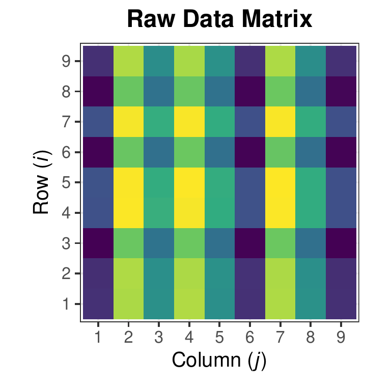

$→$

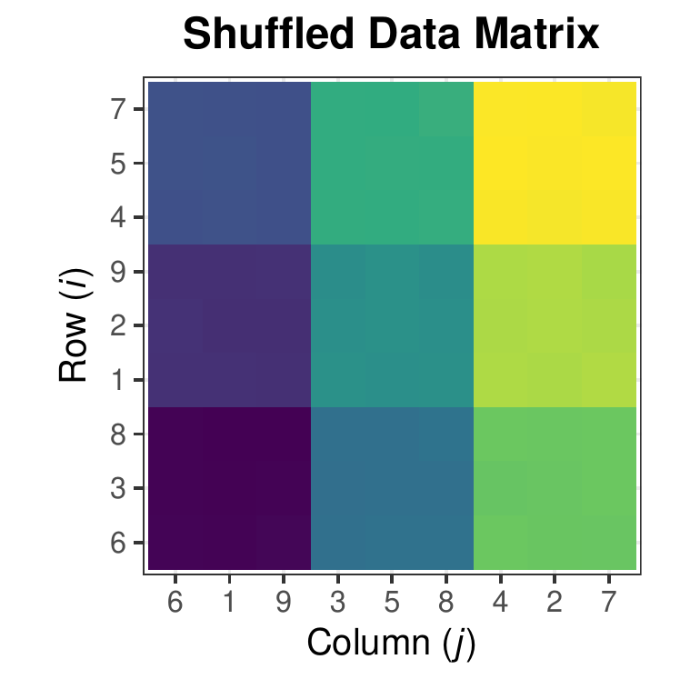

Figure 1: Biclustering with *checkerboard-like* structure

A publicly available R package for biclustering is [*biclust*](https://CRAN.R-project.org/package=biclust) by (Kaiser and Leisch 2008). This appears to be a commonly used package developed with the intent of allowing users to choose from a variety of algorithms and renderable visualizations. Other biclustering packages include [*superbiclust*](https://CRAN.R-project.org/package=superbiclust), [*iBBiG*](https://www.bioconductor.org/packages/release/bioc/html/iBBiG.html) [*QUBIC*](https://www.bioconductor.org/packages/release/bioc/html/QUBIC.html), [*s4vd*](https://CRAN.R-project.org/package=s4vd), [*BiBitR*](https://CRAN.R-project.org/package=BiBitR) which each provide unique algorithms and implementations (Khamiakova 2014; Sill and Kaiser 2015; Ewoud 2017; Zhang et al. 2017; Gusenleitner and Culhane 2019). However, from an implementation and algorithmic standpoint, the methods implemented in these packages fail when given a data matrix with missing values. This is clearly a limitation since there exist many rectangular datasets with missing values. For handling missing data, many imputation methods exist in the literature. While this does produce a complete two-way data table, which can subsequently be fully analyzed using existing biclustering algorithms, it has inherent limitations. When large percentages of data are missing, such as is, for example, common in plant breeding and movie rating applications to be discussed later, it is difficult and impossible to reasonably infer missing values. Even if a small number of values are missing values those are potentially missing not-at-random due to non-random and unknown devices. For example, in plant breeding, observation may be missing because it is unreasonable to plant a crop in a particular environment or simply because a plant breeder decides to not plant in certain environments. In these cases, imputing missing values would imply that one can confidently estimate the performance of (say) crop yield in an environment where it was never observed growing. There is a large body of literature on the difficult nature of this problem. With this as motivation, our goal was to produce a biclustering algorithm which can successfully deal with data with missing values without applying imputation or making any assumptions about why data are missing.

## 2 Biclustering with missing data

The package described in this paper, [*biclustermd*](https://CRAN.R-project.org/package=biclustermd), implements the biclustering algorithm of (Li et al. 2020) and their paper gives a thorough explanation of the proposed biclustering algorithm as well as its applicability. For completeness we give an overview of their algorithm here.

### 2.1 Notation

- $X$ is a data matrix with $I$ rows and $J$ columns. $X_{ij}$ is a response measure of row $i$ in column $j$ for $i \in \{1, 2, \dots, I\}$ and $j \in \{1, 2, \dots, J\}$.
- Row index set $\mathcal{I} = \{1, 2, \dots, I\}$ is partitioned into $r$ mutually exclusive and exhaustive sets $T_1, T_2, \dots, T_{r}$. $\mathcal{Q} \equiv$ partition of the row index set.
- Column index set $\mathcal{J} = \{1, 2, \dots, J\}$ is partitioned into $c$ mutually exclusive and exhaustive sets $S_1, S_2, \dots, S_{c}$. $\mathcal{P} \equiv$ partition of the column index set.

Our goal for biclustering is to generate a rearranged data matrix with a checkerboard structure such that each “cell” of the matrix defined by $\mathcal{Q}$ and $\mathcal{P}$ is as homogeneous as possible. Depending on specifics of a real problem, “homogeneous” can have different subject matter meanings, and hence optimization of different objective functions can be appropriate. We present our algorithm here with the goal of optimizing a total within-cluster sum of squares given both the row groups in $\mathcal{Q}$ and column groups in $\mathcal{P}$. This can be interpreted as the total sum of squared errors between cell means and data values within cells. Hence we refer to this as SSE. Using the above notations we have $r$ row groups (or row clusters) and $c$ column groups (or column clusters). Let $A$ denote an $r \times c$ “cell-average matrix” with entries
$$\label{cell_matrix}
A_{mn} \equiv \dfrac{1}{\lvert \{X_{i j} : i \in T_m; \; j \in S_n;\; X_{i j } \neq NA\} \rvert}
\sum\limits_{\{X_{ij} : i \in T_m; \; j \in S_n;\; X_{i j } \neq NA\}} X_{i j} \tag{1}$$
for $m \in 1, 2, \dots, r$ and $n \in 1, 2, \dots, c$. Here, $\lvert \cdot\rvert$ is the set cardinality function and *NA* denotes a missing value. Then, the within-cluster sum of squares function to be minimized is
$$\label{SSE}
\text{SSE} \equiv
\sum\limits_{m,n}\,\,\,
\sum\limits_{\substack{X_{i j} \neq NA\\ i \in T_m \\ j \in S_n}} \left(X_{i j} - A_{mn}\right)^2. \tag{2}$$

### 2.2 Biclustering with missing data algorithm

1. Randomly generate initial partitions $\mathcal{Q}^{\left( 0\right) }$ and $\mathcal{P}^{\left( 0\right) }$ with respectively $r$ row groups and $c$ column groups.
2. Create a matrix $A^{\left( 0\right) }$ using Equation (1) and the initial partitions. In the event that a “cell” $\left( m,n\right)$ defined by $\left\{ \left( i,j\right) |i\in T_{m}\text{ and }j\in S_{n}\right\}$ is empty, $A_{mn}$ can be set to some pre-specified constant or some function of the numerical values corresponding to the non-empty cells created by the partition. (For example, the mean of the values coming from non-empty cells in row $m$ or in column $n$ can be used.) This algorithmic step should not be seen as imputation of responses for the cell under consideration, but rather only a device to keep the algorithm running.
3. At iteration $s$ of the algorithm, with partitions $\mathcal{P}^{\left( s-1\right) }$ and $\mathcal{Q}^{\left( s-1\right) }$ and corresponding matrix $A^{\left( s-1\right) }$ in hand, for $i=1,2,\ldots,I$ let
   $$M_{in}^{R}=\frac{1}{\left\vert \left\{ j\in S_{n}|X_{ij}\neq NA\right\}
   \right\vert }\sum_{\substack{j\in S_{n}\\\text{s.t. }X_{ij}\neq NA}}X_{ij}%$$
   for each $n=1,2,\ldots,c$ and compute for $m=1,2,\ldots,r$
   $$d_{im}^{R}=\sum_{n=1}^{c}\left( A_{mn}-M_{in}^{R}\right) ^{2}\cdot\left\vert
   \left\{ j\in S_{n}|X_{ij}\neq NA\right\} \right\vert.$$
   Then create $\mathcal{Q}^{\left( s\right) \ast}$ by assigning each row $i$ to $T_{m}$ with minimum $d_{im}^{R}$.
4. If for $\mathcal{Q}^{\left( s\right) \ast}$ every $T_{m}$ is non-empty, proceed to Step 5. If at least one $T_{m}=\emptyset$ do the following:
   1. Randomly choose a row group $T_{m^{\prime}}$ with $\left\vert T_{m^{\prime}}\right\vert >k_{\text{min}}^{R}$ (a user-specified positive integer parameter) and choose $k_{\text{move}}^{R}<k_{\text{min}}^{R}$ row indices to move to one empty $T_{m}$. Choose those indices $i$ from $T_{m^{\prime}}$ with the largest $k_{\text{move}}^{R}$ corresponding values of the sum of squares
      $$\sum_{n=1}^{c}\sum_{\substack{j\in S_{n}\\\text{s.t. }X_{ij}\neq NA}}\left(
      X_{ij}-M_{in}^{R}\right) ^{2}.$$
   2. If after the move in (a) no empty row group remains, proceed to Step 5. Otherwise return to (a).
5. Replace $\mathcal{Q}^{\left( s-1\right) }$ in Step 3 with the updated version of $\mathcal{Q}^{\left( s\right) \ast}$ and cycle through Steps 3 and 4 $\alpha$ times, where $\alpha$ is a user-specified integer parameter. **If `row_shuffles` $> 1$, replace $\mathcal{Q}^{(s-1)}$ in 3. with the updated version of $\mathcal{Q}^{(s)\ast}$ and cycle through steps 3. and 4. `row_shuffles`$- 1$ times.**
6. Set $\mathcal{Q}^{\left( s\right) }=\mathcal{Q}^{\left( s\right) \ast}$. Then update $A^{\left( s-1\right) }$ to $A^{\left( s\right) \ast }$ using the partitions $\mathcal{Q}^{\left( s\right) }$ and $\mathcal{P}% ^{\left( s-1\right) }$ in Equation (1).
7. For $j=1,2,\ldots,J$ let
   $$M_{jm}^{C}=\frac{1}{\left\vert \left\{ i\in T_{m}|X_{ij}\neq NA\right\}
   \right\vert }\sum_{\substack{i\in T_{m} \\ \text{s.t.} X_{ij} \neq NA}}X_{ij}$$
   for each $m=1,2,\ldots,r$ and compute for $n=1,2,\ldots,c$
   $$d_{jn}^{C}=\sum_{m=1}^{r}\left( A_{mn}-M_{jm}^{C}\right) ^{2}\cdot\left\vert
   \left\{ i\in T_{m}|X_{ij}\neq NA\right\} \right\vert.$$
   Then create $\mathcal{P}^{\left( s\right) \ast}$ by assigning each column $j$ to $S_{n}$ with minimum $d_{jn}^{C}$.
8. If for $\mathcal{P}^{\left( s\right) \ast}$ every $S_{n}$ is non-empty, proceed to Step 9. If at least one $S_{n}=\emptyset$ do the following:
   1. Randomly choose a column group $S_{n^{\prime}}$ with $\left\vert S_{n^{\prime}}\right\vert >k_{\text{min}}^{C}$ (a user-specified positive integer parameter) and choose $k_{\text{move}}^{C}<k_{\text{min}}^{C}$ column indices to move to one empty $S_{n}$. Choose those indices $j$ from $S_{n^{\prime}}$ with the largest $k_{\text{move}}^{C}$ corresponding values of the sum of squares
      $$\sum_{m=1}^{r}\sum_{\substack{i\in T_{m}\\\text{s.t. }X_{ij}\neq NA}}\left(
      X_{ij}-M_{jm}^{C}\right) ^{2}.$$
   2. If after the move in (a) no empty column group remains, proceed to Step 9. Otherwise return to (a).
9. Replace $\mathcal{P}^{\left( s-1\right) }$ in Step 3 with the updated version of $\mathcal{P}^{\left( s\right) \ast}$ and cycle through Steps 7 and 8 $\beta$ times, where $\beta$ is a user-specified integer parameter. If `col_shuffles` $> 1$, replace $\mathcal{P}^{(s-1)}$ in 3. with the updated version of $\mathcal{P}^{(s)\ast}$ and cycle through steps 7. and 8. `col_shuffles`$- 1$ times.
10. Set $\mathcal{P}^{\left( s \right)} = \mathcal{P}^{\left( s \right) \ast}$ and we have new partitions $\mathcal{Q}^{(s)}$ and $\mathcal{P}^{(s)}$. Then update $A^{\left( s \right) \ast}$ to $A^{\left( s \right) }$ using the partitions $\mathcal{Q}^{\left( s \right)}$ and $\mathcal{P}% ^{\left( s \right) }$ in Equation (1).
11. Steps 3–10 are executed $N$ times or until the algorithm converges, which is when the Rand Indices for successive row and column partitions are both 1. (See the description of the Rand Index below.)

Intuitively, our proposed algorithm is nothing more than a rearrangement of rows and columns with the objective to minimize the objectives given in Steps 3 and 7. We consider Step 1 (the random generation of initial cluster assignments) to be of high importance to avoid any bias in the original structure of the data. As a quantitative way to measure the effectiveness of our biclustering, we consider the sum of squared errors (SSE) as the measure of within cell homogeneity. Paired with the SSE, we allow for three different convergence criteria, the Rand Index (Rand 1971), the Adjusted Rand Index (Hubert and Arabie 1985), and the Jaccard Index (Goodall 1966). These indices provide measures for the similarity between two clusterings.